# Machine Learning - Final Project

Ken Koch

# Executive Summary

This project is an analysis of Human Activity Recognition exercises and the training of data models to predict the ‘classe’ outcome which indicates whether an individual corrrectly performed an exercise (value of ‘A’) or incorrectly performed it in one of four alternative ways (value of ‘B’, ‘C’, ‘D’, or ‘E’).

Using Random Forest prediction with k-Fold Cross Validation (k=10), the classe variable can be predicted with an accuracy rate of 99% and an Out-of-Bag(OOB) sample error of 0.65%.

# Background

The data used for this project comes from the Human Activity Recognition project (http://groupware.les.inf.puc-rio.br/har).

The training data can be acquired here: https://d396qusza40orc.cloudfront.net/predmachlearn/pml-training.csv

The testing data can be acquired here: https://d396qusza40orc.cloudfront.net/predmachlearn/pml-testing.csv

The following packages were used in the compiling of this data:

```r
library(datasets)
library(dplyr)
library(ggplot2)
library(GGally)
library(caret)
library(rlist)

set.seed(23456)

#Load the training and testing data (ensure that the working directory is set to the file locations)
training <- read.csv("pml-training.csv", na.strings=c('#DIV/0!', '', 'NA'))
testing <- read.csv("pml-testing.csv", na.strings=c('#DIV/0!', '', 'NA'))
```

# Analysis of the Data

As shown below, the training data was cleaned to remove empty columns and summary columns. The summary data was then identified and the detailed training data was separated from the summary training data.

```r
#Let's find any columns in training for which there isn't any data
emptyColumns <- apply(training, 2, function(x){all(is.na(x))})
trainingDetail <- training[,-which(emptyColumns==TRUE)]

#There is a typo in the name of column 17, let's fix it (max_picth_belt)
names(trainingDetail)[17] <- "max_pitch_belt"

#max_pitch_belt is one of the columns that only applies to summary records,
#so we'll use it to tag those records
isSummary <- apply(trainingDetail, 1, function(x){!is.na(x[17])})

#Let's pull the summary records out of the trainingDetail set
trainingSummary <- trainingDetail[which(isSummary==TRUE),]
trainingDetail <- trainingDetail[-which(isSummary==TRUE),]

#All of the summary columns in the detail records are empty and don't add
#any value. Let's get rid of them.
emptyColumns <- apply(trainingDetail, 2, function(x){all(is.na(x))})

#Remove the empty factor columns from the detail data
trainingDetail <- trainingDetail[-which(emptyColumns==TRUE)]

#Let's take a look at the testing data to see if it is detail or summary data.
#If it is detail data, it will have NAs in the summary columns
NAs <- apply(testing, 1, function(x){anyNA(x)})
```

```r
# Check the number of rows in the testing dataset that are detail records
length(NAs[NAs == TRUE])
```

```
## [1] 20
```

```r
# Validate it against the total rows in the testing dataset
nrow(testing)
```

```
## [1] 20
```

Given that the total rows and the number of detail rows in the testing data set are equal, the detailed training data is initially targeted for creating the prediction model.

Next, a correlation table was created on the detailed records to determine which variables were highly correlated (>75%). Using that data, an ommission list of variables was computed and those variables were removed from the detailed training data.

```r
#Let's throw away the first 7 columns of information; they contain user and
#date/time information that we will assume (for now) do not have an impact on
#the result of the "classe" variable. This leaves us with 53 columns, including #the 'classe' variable.
trainingDetail <- trainingDetail[,8:60]

#Let's compute a correlation table for everything but the 'classe' variable so
#we can see which columns are highly correlated
corTable <- cor(trainingDetail[1:52])

#Let's create an ommission list of columns that we won't need because they are
#highly correlated with other columns and, thus, are redundant.
omitList <- apply(corTable, 1, function(x){which((abs(x) > 0.75 & x != 1.000000000)==TRUE)})
omitList <- unlist(omitList) #Flatten the list of lists into a single list
omitList <- list.sort(unique(as.integer(omitList)))
omitList <- omitList[-1]  #Get rid of the 1st element since we want to keep it

#trainingSummary <- trainingSummary[, -omitList]
trainingDetail <- trainingDetail[, -omitList]
```

# Cross Validation and Building the Classification Models

Cross validation was then configured using the K-Fold method with 10 folds.

```r
# Set up K-Fold Cross-Validation (10 folds) for use in our model training
trainCtl <- trainControl(method = "cv", 10)
```

Next, a Random Forest classification model was created for the detailed training data. The outputs from the random forest and the final model are shown below.

```r
modelFitDetailRf <- train(classe ~ ., method = "rf", data = trainingDetail, trControl = trainCtl)
```

```
## Random Forest
##
## 19216 samples
##    20 predictor
##     5 classes: 'A', 'B', 'C', 'D', 'E'
##
## No pre-processing
## Resampling: Cross-Validated (10 fold)
## Summary of sample sizes: 17296, 17294, 17294, 17294, 17295, 17293, ...
## Resampling results across tuning parameters:
##
##   mtry  Accuracy   Kappa
##    2    0.9929231  0.9910475
##   11    0.9908418  0.9884152
##   20    0.9851176  0.9811734
##
## Accuracy was used to select the optimal model using  the largest value.
## The final value used for the model was mtry = 2.
```

```
##
## Call:
##  randomForest(x = x, y = y, mtry = param$mtry)
##                Type of random forest: classification
##                      Number of trees: 500
## No. of variables tried at each split: 2
##
##         OOB estimate of  error rate: 0.65%
## Confusion matrix:
##      A    B    C    D    E class.error
## A 5465    4    2    0    0 0.001096692
## B   15 3689   12    0    2 0.007799892
## C    0   21 3320   11    0 0.009546539
## D    0    0   45 3099    3 0.015252622
## E    0    1    3    5 3519 0.002551020
```

The model created from the detailed training records yields strong results with an accuracy of 99.29% and an OOB error rate of 0.65%.

While the results are strong, adding the summary records back into the model could improve the results since these records also include detail information from the last observation in each set of records.

```r
#We have to have the same columns from the summary data that are in the detail data
trainingCombined <- rbind(trainingDetail, trainingSummary[,names(trainingSummary) %in% names(trainingDetail)])

modelFitCombinedRf <- train(classe ~ ., method = "rf", data = trainingCombined, na.action = na.exclude, trControl = trainCtl)
```

```
## Random Forest
##
## 19622 samples
##    20 predictor
##     5 classes: 'A', 'B', 'C', 'D', 'E'
##
## No pre-processing
## Resampling: Cross-Validated (10 fold)
## Summary of sample sizes: 17660, 17660, 17660, 17658, 17659, 17660, ...
## Resampling results across tuning parameters:
##
##   mtry  Accuracy   Kappa
##    2    0.9929157  0.9910386
##   11    0.9906229  0.9881395
##   20    0.9847112  0.9806616
##
## Accuracy was used to select the optimal model using  the largest value.
## The final value used for the model was mtry = 2.
```

```
##
## Call:
##  randomForest(x = x, y = y, mtry = param$mtry)
##                Type of random forest: classification
##                      Number of trees: 500
## No. of variables tried at each split: 2
##
##         OOB estimate of  error rate: 0.63%
## Confusion matrix:
##      A    B    C    D    E  class.error
## A 5575    4    1    0    0 0.0008960573
## B   10 3774   12    0    1 0.0060574137
## C    0   23 3388   10    1 0.0099357101
## D    0    0   49 3163    4 0.0164800995
## E    0    1    2    6 3598 0.0024951483
```

As shown above, the model results from the recombination of the detailed training data with the relevant variables from the summary training data yield a better result with accuracy remaining at 99.29% and an OOB error rate of 0.63%

The plot below shows a small decline in the accuracy of the model (0.8%) as the number of predictors in the model increases with the low end of the accuracy range at 98.4% for 20 predictors.

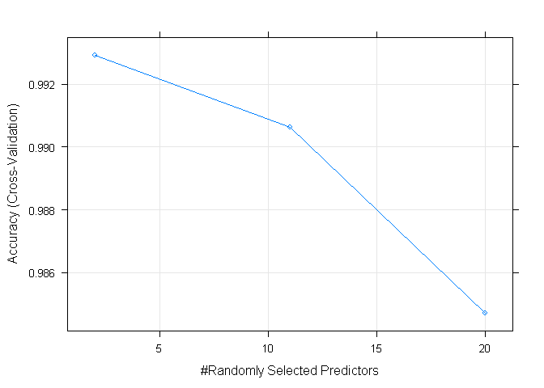

```r
plot(modelFitCombinedRf)
```

Plotting the error rate for each outcome against the number of trees in the model (see below) shows that the model reaches a stable point at just over 100 trees, indicating that the model scale was adequate to achieve the result.

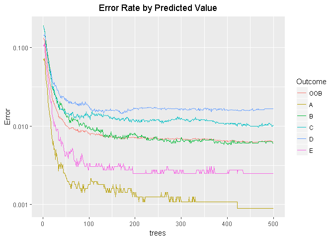

```r
library(data.table)
plotData <- as.data.table(modelFitCombinedRf$finalModel$err.rate)
plotData$trees <- plotData[, .I]
plotData = melt(plotData, id.vars = "trees")
names(plotData)[2] <- "Outcome"
names(plotData)[3] <- "Error"
ggplot(as.data.frame(plotData), aes(x = trees, y = Error, color = Outcome)) + geom_line() + scale_y_log10() + ggtitle("Error Rate by Predicted Value") +
    theme(plot.title = element_text(hjust = 0.5))
```

Plotting the margin shows that the classifiers for the ‘classe’ variable are correct and there was sufficent data available in the training set to achieve a near perfect classification.

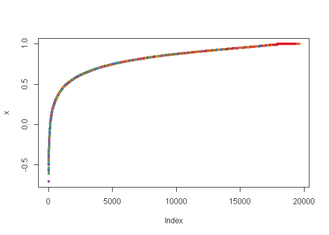

```r
plot(margin(modelFitCombinedRf$finalModel, trainingCombined$classe))
```

# Conclusion

Using the final model, we can confidently predict the ‘classe’ outcomes of the 20 records in the testing data set with an accuracy of 99%. The predicted results are shown below.

```r
predict(modelFitCombinedRf, testing)
```

```
##  [1] B A B A A E D B A A B C B A E E A B B B
## Levels: A B C D E
```

**- End of Report -**